# Unemployment_prediction_Test

### Applied Machine Learning Homework 1 Question 1

```python
import pandas as pd
import numpy as np
import matplotlib.pyplot as plt
import seaborn as sns

import warnings
warnings.filterwarnings('ignore')

# Load dataset
df = pd.read_csv('Walmart_Sales.csv')

print("Number of rows: ", df.shape[0]," \nNumber of columns: ", df.shape[1])

# Separate continuous and categorical features
continuous_cols = df.select_dtypes(include=['float64', 'int64']).columns
categorical_cols = df.select_dtypes(include=['object', 'category']).columns

print(f"\nContinuous Features:\n{continuous_cols}")
print(f"\nCategorical Features:\n{categorical_cols}")
```

```
Number of rows:  6435
Number of columns:  8

Continuous Features:
Index(['Store', 'Weekly_Sales', 'Holiday_Flag', 'Temperature', 'Fuel_Price',
       'CPI', 'Unemployment'],
      dtype='object')

Categorical Features:
Index(['Date'], dtype='object')
```

```python
print(df.describe())
```

```
             Store  Weekly_Sales  Holiday_Flag  Temperature   Fuel_Price  \
count  6435.000000  6.435000e+03   6435.000000  6435.000000  6435.000000
mean     23.000000  1.046965e+06      0.069930    60.663782     3.358607
std      12.988182  5.643666e+05      0.255049    18.444933     0.459020
min       1.000000  2.099862e+05      0.000000    -2.060000     2.472000
25%      12.000000  5.533501e+05      0.000000    47.460000     2.933000
50%      23.000000  9.607460e+05      0.000000    62.670000     3.445000
75%      34.000000  1.420159e+06      0.000000    74.940000     3.735000
max      45.000000  3.818686e+06      1.000000   100.140000     4.468000

               CPI  Unemployment
count  6435.000000   6435.000000
mean    171.578394      7.999151
std      39.356712      1.875885
min     126.064000      3.879000
25%     131.735000      6.891000
50%     182.616521      7.874000
75%     212.743293      8.622000
max     227.232807     14.313000
```

```python
print(df.head())
```

```
   Store        Date  Weekly_Sales  Holiday_Flag  Temperature  Fuel_Price  \
0      1  05-02-2010    1643690.90             0        42.31       2.572
1      1  12-02-2010    1641957.44             1        38.51       2.548
2      1  19-02-2010    1611968.17             0        39.93       2.514
3      1  26-02-2010    1409727.59             0        46.63       2.561
4      1  05-03-2010    1554806.68             0        46.50       2.625

          CPI  Unemployment
0  211.096358         8.106
1  211.242170         8.106
2  211.289143         8.106
3  211.319643         8.106
4  211.350143         8.106
```

```python
print(df.info())
```

```
<class 'pandas.core.frame.DataFrame'>
RangeIndex: 6435 entries, 0 to 6434
Data columns (total 8 columns):
 #   Column        Non-Null Count  Dtype
---  ------        --------------  -----
 0   Store         6435 non-null   int64
 1   Date          6435 non-null   object
 2   Weekly_Sales  6435 non-null   float64
 3   Holiday_Flag  6435 non-null   int64
 4   Temperature   6435 non-null   float64
 5   Fuel_Price    6435 non-null   float64
 6   CPI           6435 non-null   float64
 7   Unemployment  6435 non-null   float64
dtypes: float64(5), int64(2), object(1)
memory usage: 402.3+ KB
None
```

### Summarization of Data

In this subquestion the shape of the data is determined with the categorical and continuous features. The data statistics are further analysed.

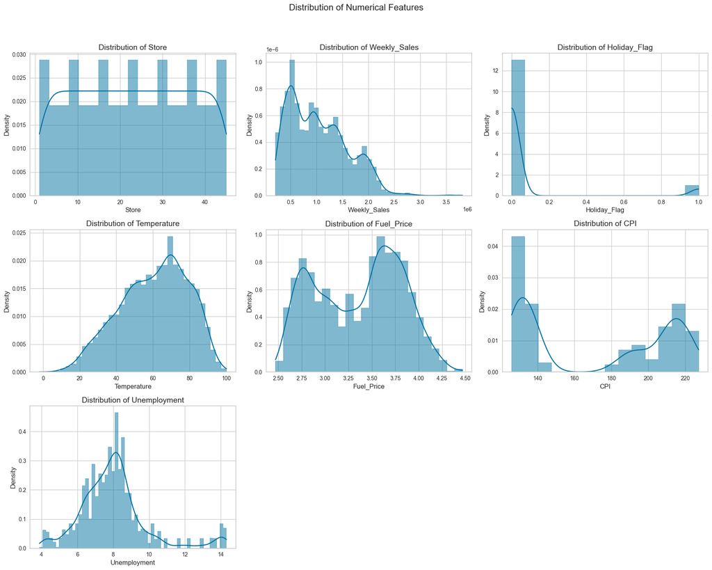

```python
# Histogram
numerical_columns = df.select_dtypes(include=['number']).columns

num_cols = 3
num_rows = (len(numerical_columns) + num_cols - 1) // num_cols

fig, axes = plt.subplots(num_rows, num_cols, figsize=(18, 5 * num_rows))
fig.suptitle("Distribution of Numerical Features", fontsize=16)

axes = axes.flatten()

for i, col in enumerate(numerical_columns):
    sns.histplot(df[col], kde=True, ax=axes[i], palette="viridis", element='step', stat='density')
    axes[i].set_title(f'Distribution of {col}', fontsize=14)
    axes[i].set_xlabel(col, fontsize=12)
    axes[i].set_ylabel('Density', fontsize=12)

for j in range(i + 1, len(axes)):
    fig.delaxes(axes[j])

plt.tight_layout(rect=[0, 0.03, 1, 0.95])
plt.show()
```

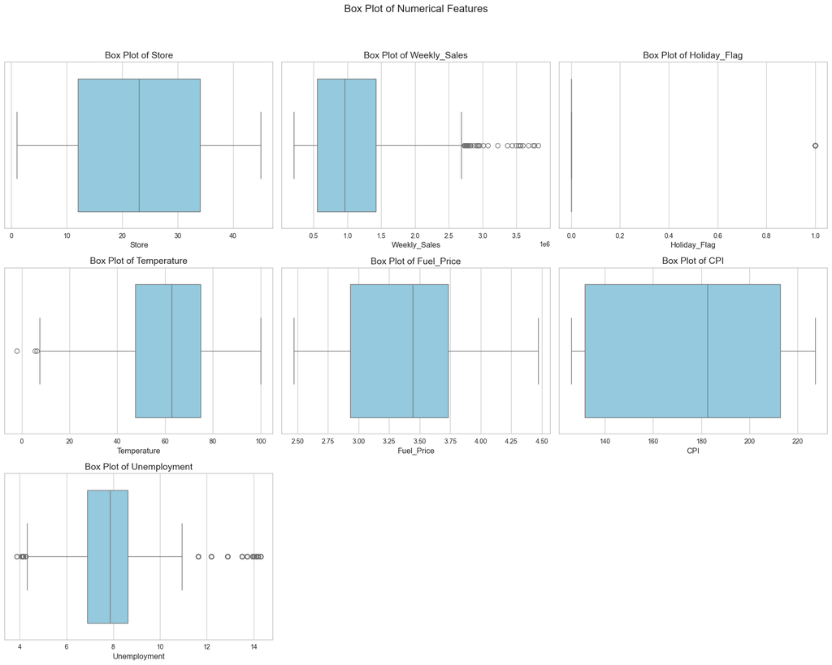

```python
# Box Plot
numerical_columns = df.select_dtypes(include=['number']).columns

num_cols = 3
num_rows = (len(numerical_columns) + num_cols - 1) // num_cols

fig, axes = plt.subplots(num_rows, num_cols, figsize=(18, 5 * num_rows))
fig.suptitle('Box Plot of Numerical Features', fontsize=16)

axes = axes.flatten()

for i, col in enumerate(numerical_columns):
    sns.boxplot(x=df[col], ax=axes[i], color="skyblue")
    axes[i].set_title(f'Box Plot of {col}', fontsize=14)
    axes[i].set_xlabel(col, fontsize=12)

for j in range(i + 1, len(axes)):
    fig.delaxes(axes[j])

plt.tight_layout(rect=[0, 0.03, 1, 0.95])
plt.show()
```

```python
# Check for missing values
print("\nMissing Values:")
missing_values = df.isnull().sum()
print(missing_values)
```

```
Missing Values:
Store           0
Date            0
Weekly_Sales    0
Holiday_Flag    0
Temperature     0
Fuel_Price      0
CPI             0
Unemployment    0
dtype: int64
```

```python
# Check for outliers
def detect_outliers(df, col):
    Q1 = df[col].quantile(0.25)
    Q3 = df[col].quantile(0.75)
    IQR = Q3 - Q1
    lower_bound = Q1 - 1.5 * IQR
    upper_bound = Q3 + 1.5 * IQR
    outliers = df[(df[col] < lower_bound) | (df[col] > upper_bound)]
    return len(outliers)

print("\nNumber of outliers:")
for col in continuous_cols:
    print(f"{col}: {detect_outliers(df, col)}")

# Handle Outliers
for column in df.select_dtypes(include=['number']).columns:
    Q1 = df[column].quantile(0.25)
    Q3 = df[column].quantile(0.75)
    IQR = Q3 - Q1
    lower_bound = Q1 - 1.5 * IQR
    upper_bound = Q3 + 1.5 * IQR

    df[column] = df[column].clip(lower=lower_bound, upper=upper_bound)
```

```
Number of outliers:
Store: 0
Weekly_Sales: 34
Holiday_Flag: 450
Temperature: 3
Fuel_Price: 0
CPI: 0
Unemployment: 481
```

### Missing Values:

The data is checked for missing values in the dataset using isnull().sum(), and found that there are no missing values in any of the columns. This is a positive trait, as it means you won’t need to deal with data imputation or removal due to missing data.

```python
# Pearson Correlation
df.corr(method='pearson', numeric_only=True)
```

|  | Store | Weekly_Sales | Holiday_Flag | Temperature | Fuel_Price | CPI | Unemployment |
| --- | --- | --- | --- | --- | --- | --- | --- |
| Store | 1.000000e+00 | -0.335332 | -4.386841e-16 | -0.022659 | 0.060023 | -0.209492 | 0.223531 |
| Weekly_Sales | -3.353320e-01 | 1.000000 | 3.689097e-02 | -0.063810 | 0.009464 | -0.072634 | -0.106176 |
| Holiday_Flag | -4.386841e-16 | 0.036891 | 1.000000e+00 | -0.155091 | -0.078347 | -0.002162 | 0.010960 |
| Temperature | -2.265908e-02 | -0.063810 | -1.550913e-01 | 1.000000 | 0.144982 | 0.176888 | 0.101158 |
| Fuel_Price | 6.002295e-02 | 0.009464 | -7.834652e-02 | 0.144982 | 1.000000 | -0.170642 | -0.034684 |
| CPI | -2.094919e-01 | -0.072634 | -2.162091e-03 | 0.176888 | -0.170642 | 1.000000 | -0.302020 |
| Unemployment | 2.235313e-01 | -0.106176 | 1.096028e-02 | 0.101158 | -0.034684 | -0.302020 | 1.000000 |

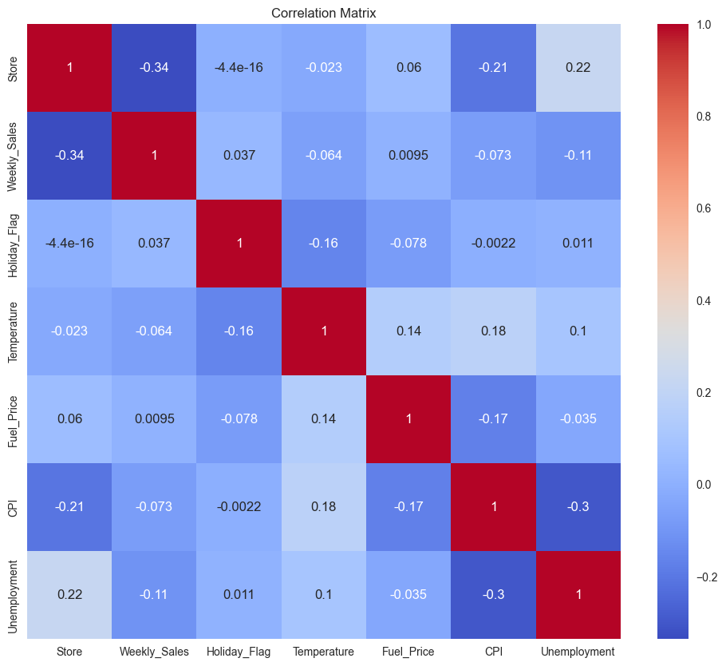

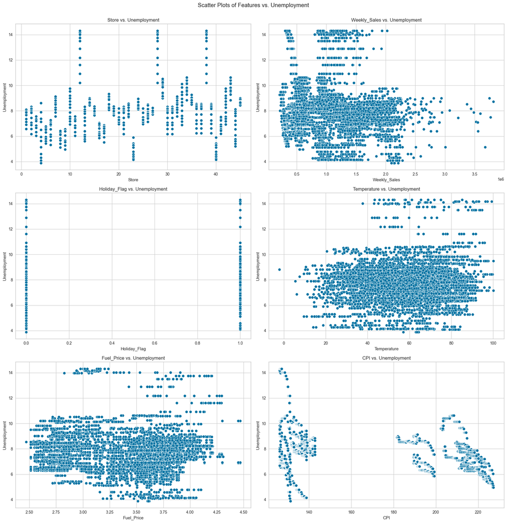

```python
# Heatmap of continuous values
correlation_matrix = df[continuous_cols].corr()

plt.figure(figsize=(12, 10))
sns.heatmap(correlation_matrix, annot=True, cmap='coolwarm')
plt.title('Correlation Matrix')
plt.show()


# Plot of Scatter for Unemployment vs continuous values
import matplotlib.pyplot as plt
import seaborn as sns

fig, axes = plt.subplots(3, 2, figsize=(18, 18))
x_vars = ['Store', 'Weekly_Sales', 'Holiday_Flag', 'Temperature', 'Fuel_Price', 'CPI']

for ax, x_var in zip(axes.flatten(), x_vars):
    sns.scatterplot(data=df, x=x_var, y='Unemployment', ax=ax)
    ax.set_title(f'{x_var} vs. Unemployment')
    ax.set_xlabel(x_var)
    ax.set_ylabel('Unemployment')

plt.tight_layout()
plt.suptitle('Scatter Plots of Features vs. Unemployment', y=1.02)
plt.show()
```

### Correlation matrix Heatmap

Store size or location could be a significant factor influencing weekly sales. Economic conditions (CPI and Unemployment) might have a weaker impact on weekly sales compared to store-specific factors. Seasonal factors (related to holidays or temperature) might have a minimal effect on the overall sales.

```python
from sklearn.model_selection import train_test_split
from sklearn.preprocessing import StandardScaler

target = 'Unemployment'
drop = [target, 'Date']
X = df.drop(columns=drop, axis = 1)
y = df[target]

X_train, X_test, y_train, y_test = train_test_split(X, y, test_size=0.25, random_state=42)

print("Full dataset mean:", y.mean())
print("Test set mean:", y_test.mean())

print("\nFull dataset std:", y.std())
print("Test set std:", y_test.std())
```

```
Full dataset mean: 7.871208313908314
Test set mean: 7.855452144188937

Full dataset std: 1.5206938208999887
Test set std: 1.5244441213892517
```

```python
print(X_train.shape)
print(X_test.shape)
print(y_train.shape)
print(y_test.shape)
```

```
(4826, 6)
(1609, 6)
(4826,)
(1609,)
```

```python
from sklearn.linear_model import LinearRegression
from sklearn.model_selection import KFold
from sklearn.metrics import r2_score, mean_squared_error, accuracy_score

kf = KFold(n_splits=3, shuffle = True, random_state=42)

linear_model=LinearRegression().fit(X_train,y_train)
linear_model_pred=linear_model.predict(X_test)
# print("Accuracy: ",accuracy_score(y_test, linear_model_pred))
print("RMSE:",np.sqrt(mean_squared_error(y_test,linear_model_pred)))
print("R*2:",r2_score(y_test,linear_model_pred))
```

```
RMSE: 1.3934340861611314
R*2: 0.1639738922706434
```

```python
import numpy as np
from sklearn.metrics import mean_squared_error
from sklearn.model_selection import train_test_split, cross_val_score
from sklearn.preprocessing import StandardScaler
from sklearn.impute import SimpleImputer
from sklearn.linear_model import SGDRegressor
from sklearn.pipeline import make_pipeline

def create_pipeline(model):
    return make_pipeline(
        SimpleImputer(strategy='mean'),
        StandardScaler(),
        model
    )

# Closed-form solution
lr_pipeline = create_pipeline(LinearRegression())
lr_scores = cross_val_score(lr_pipeline, X_train, y_train, cv=kf, scoring='neg_mean_squared_error')
print("Closed-form MSE:", -lr_scores.mean())

# SGD
sgd_pipeline = create_pipeline(SGDRegressor(max_iter=1000, tol=1e-3, random_state=42))
sgd_scores = cross_val_score(sgd_pipeline, X_train, y_train, cv=kf, scoring='neg_mean_squared_error')
print("SGD MSE:", -sgd_scores.mean())
```

```
Closed-form MSE: 1.9568240441908575
SGD MSE: 1.9586497298327867
```

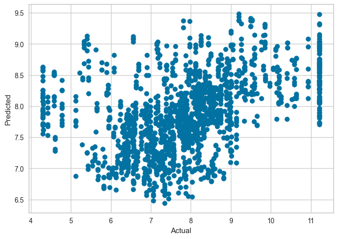

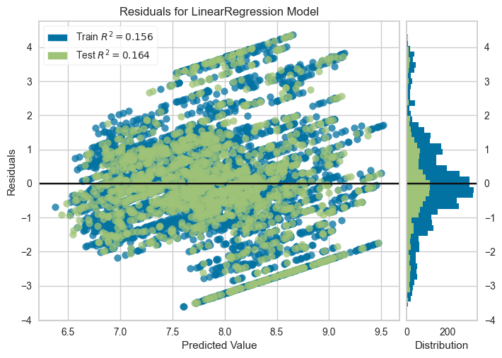

```python
import numpy as np
from sklearn.linear_model import LinearRegression
from yellowbrick.regressor import PredictionError, ResidualsPlot

linear_model = LinearRegression()
linear_model.fit(X_train, y_train)

# Prediction Plot
plt.scatter(y_test, linear_model_pred)
plt.xlabel('Actual')
plt.ylabel('Predicted')
plt.show()

# ResidualsPlot visualizer
residuals_viz = ResidualsPlot(linear_model)
residuals_viz.fit(X_train, y_train)
residuals_viz.score(X_test, y_test)
residuals_viz.show()
```

```python
import numpy as np
from sklearn.linear_model import Ridge, Lasso, ElasticNet
from sklearn.metrics import mean_squared_error
import matplotlib.pyplot as plt

penalty_terms = [0.1, 1.0, 10.0]

ridge_mse, lasso_mse, elastic_net_mse = [], [], []

# Ridge Regression
for alpha in penalty_terms:
    ridge_model = Ridge(alpha=alpha)
    ridge_model.fit(X_train, y_train)
    y_pred = ridge_model.predict(X_test)
    mse = mean_squared_error(y_test, y_pred)
    ridge_mse.append(mse)
    print(f'Ridge Regression (alpha={alpha}): MSE = {mse:.4f}')

# Lasso Regression
for alpha in penalty_terms:
    lasso_model = Lasso(alpha=alpha)
    lasso_model.fit(X_train, y_train)
    y_pred = lasso_model.predict(X_test)
    mse = mean_squared_error(y_test, y_pred)
    lasso_mse.append(mse)
    print(f'Lasso Regression (alpha={alpha}): MSE = {mse:.4f}')

# Elastic Net Regression
for alpha in penalty_terms:
    elastic_net_model = ElasticNet(alpha=alpha, l1_ratio=0.5)
    elastic_net_model.fit(X_train, y_train)
    y_pred = elastic_net_model.predict(X_test)
    mse = mean_squared_error(y_test, y_pred)
    elastic_net_mse.append(mse)
    print(f'Elastic Net Regression (alpha={alpha}): MSE = {mse:.4f}')
```

```
Ridge Regression (alpha=0.1): MSE = 1.9417
Ridge Regression (alpha=1.0): MSE = 1.9417
Ridge Regression (alpha=10.0): MSE = 1.9417
Lasso Regression (alpha=0.1): MSE = 1.9857
Lasso Regression (alpha=1.0): MSE = 1.9965
Lasso Regression (alpha=10.0): MSE = 2.1716
Elastic Net Regression (alpha=0.1): MSE = 1.9611
Elastic Net Regression (alpha=1.0): MSE = 1.9885
Elastic Net Regression (alpha=10.0): MSE = 2.1139
```

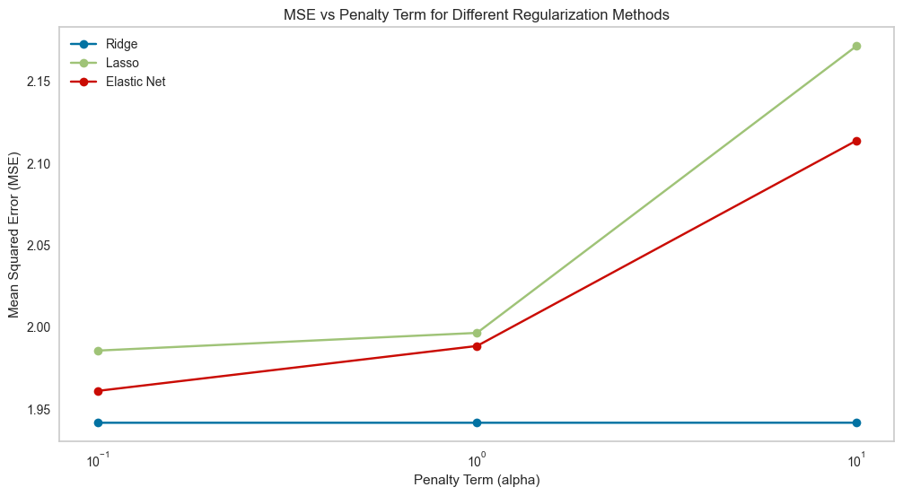

```python
#Plotting the results
plt.figure(figsize=(12, 6))
plt.plot(penalty_terms, ridge_mse, marker='o', label='Ridge')
plt.plot(penalty_terms, lasso_mse, marker='o', label='Lasso')
plt.plot(penalty_terms, elastic_net_mse, marker='o', label='Elastic Net')
plt.xscale('log')
plt.xlabel('Penalty Term (alpha)')
plt.ylabel('Mean Squared Error (MSE)')
plt.title('MSE vs Penalty Term for Different Regularization Methods')
plt.legend()
plt.grid()
plt.show()
```

```python
from sklearn.linear_model import SGDRegressor
from sklearn.model_selection import cross_val_score
from sklearn.pipeline import make_pipeline
from sklearn.impute import SimpleImputer
from sklearn.preprocessing import StandardScaler

def create_pipeline(model):
    return make_pipeline(
        SimpleImputer(strategy='mean'),
        StandardScaler(),
        model
    )

# Hyperparameter values to explore
learning_rates = [0.001, 0.01, 0.1]
batch_sizes = [1, 100, 1000]
results = []
print("SGD MSE\n")
for learning_rate in learning_rates:
    for batch_size in batch_sizes:

        max_iter = 1000 // batch_size
        sgd_pipeline = create_pipeline(SGDRegressor(max_iter=max_iter, tol=1e-3, learning_rate='constant', eta0=learning_rate, random_state=42))

        sgd_scores = cross_val_score(sgd_pipeline, X_train, y_train, cv=kf, scoring='neg_mean_squared_error')
        mean_score = -sgd_scores.mean()
        print(f"Learning rate({learning_rate}) batch size {batch_size}: {mean_score}")

        results.append((learning_rate, batch_size, mean_score))
```

```
SGD MSE

Learning rate(0.001) batch size 1: 1.9608054430324227
Learning rate(0.001) batch size 100: 1.9608054430324227
Learning rate(0.001) batch size 1000: 2.0807115183816234
Learning rate(0.01) batch size 1: 2.0235241017934875
Learning rate(0.01) batch size 100: 2.0235241017934875
Learning rate(0.01) batch size 1000: 1.9971077801978347
Learning rate(0.1) batch size 1: 3.024741423569761
Learning rate(0.1) batch size 100: 2.826262242205569
Learning rate(0.1) batch size 1000: 2.253276238365509
```

```
[1.96080544 1.96080544 2.08071152 2.0235241  2.0235241  1.99710778
 3.02474142 2.82626224 2.25327624]
```

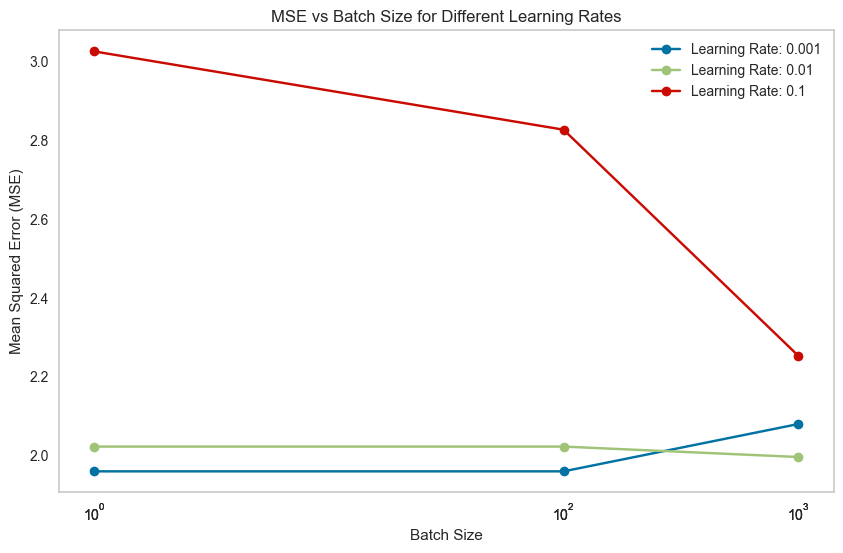

```python
results = np.array(results)
learning_rates = results[:, 0]
batch_sizes = results[:, 1]
mse_values = results[:, 2]

print(mse_values)

# Visualize results
plt.figure(figsize=(10, 6))
for lr in np.unique(learning_rates):
    mask = learning_rates == lr
    plt.plot(batch_sizes[mask], mse_values[mask], marker='o', label=f'Learning Rate: {lr}')

plt.xscale('log')
plt.xlabel('Batch Size')
plt.ylabel('Mean Squared Error (MSE)')
plt.title('MSE vs Batch Size for Different Learning Rates')
plt.xticks(batch_sizes)
plt.legend()
plt.grid()
plt.show()
```

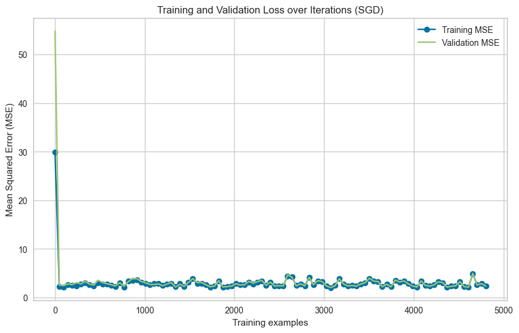

```python
train_scores, valid_scores = [], []
train_sizes = range(1, len(X_train), len(X_train) // 100)

for size in train_sizes:
    sgd_pipeline.fit(X_train[:size], y_train[:size])
    train_scores.append(mean_squared_error(y_train[:size], sgd_pipeline.predict(X_train[:size])))
    valid_scores.append(mean_squared_error(y_test, sgd_pipeline.predict(X_test)))

plt.figure(figsize=(10,6))
plt.plot(train_sizes, train_scores, label='Training MSE', marker='o')
plt.plot(train_sizes, valid_scores, label='Validation MSE', marker='x')
plt.legend()
plt.xlabel('Training examples')
plt.ylabel('Mean Squared Error (MSE)')
plt.title('Training and Validation Loss over Iterations (SGD)')
plt.show()
```

```python
from sklearn.preprocessing import PolynomialFeatures
from sklearn.model_selection import cross_val_score
from sklearn.linear_model import LinearRegression
from sklearn.impute import SimpleImputer


# Transform the features to polynomial features
degree = 6
poly = PolynomialFeatures(degree)
X_train_poly = poly.fit_transform(X_train)
X_test_poly = poly.transform(X_test)


# Linear Regression with Closed-Form Solution
lin_reg = LinearRegression()

# Perform three-fold cross-validation
scores = cross_val_score(lin_reg, X_train_poly, y_train, scoring='neg_mean_squared_error', cv=kf)
mse_scores = -scores

print("Poly Cross-Validation MSE Scores (Closed-Form):", mse_scores)
print("Poly Mean CV MSE (Closed-Form):", np.mean(mse_scores))
```

```
Poly Cross-Validation MSE Scores (Closed-Form): [4.87174545 2.76625204 2.4279651 ]
Poly Mean CV MSE (Closed-Form): 3.3553208644158516
```

```python
from sklearn.linear_model import Ridge, Lasso, ElasticNet

# Regularization strengths to test
penalty_terms = [0.1, 1.0, 10.0]

ridge_mse, lasso_mse, elastic_net_mse = [], [], []

# Ridge Regression
for alpha in penalty_terms:
    ridge_model = Ridge(alpha=alpha)
    ridge_model.fit(X_train_poly, y_train)
    y_pred = ridge_model.predict(X_test_poly)
    mse = mean_squared_error(y_test, y_pred)
    ridge_mse.append(mse)
    print(f'Poly Ridge Regression (alpha={alpha}): MSE = {mse:.4f}')

# Lasso Regression
for alpha in penalty_terms:
    lasso_model = Lasso(alpha=alpha)
    lasso_model.fit(X_train_poly, y_train)
    y_pred = lasso_model.predict(X_test_poly)
    mse = mean_squared_error(y_test, y_pred)
    lasso_mse.append(mse)
    print(f'Poly Lasso Regression (alpha={alpha}): MSE = {mse:.4f}')

# Elastic Net Regression
for alpha in penalty_terms:
    elastic_net_model = ElasticNet(alpha=alpha, l1_ratio=0.5)
    elastic_net_model.fit(X_train_poly, y_train)
    y_pred = elastic_net_model.predict(X_test_poly)
    mse = mean_squared_error(y_test, y_pred)
    elastic_net_mse.append(mse)
    print(f'Poly Elastic Net Regression (alpha={alpha}): MSE = {mse:.4f}')
```

```
Poly Ridge Regression (alpha=0.1): MSE = 0.3806
Poly Ridge Regression (alpha=1.0): MSE = 0.3782
Poly Ridge Regression (alpha=10.0): MSE = 0.3739
Poly Lasso Regression (alpha=0.1): MSE = 1.0230
Poly Lasso Regression (alpha=1.0): MSE = 1.0303
Poly Lasso Regression (alpha=10.0): MSE = 1.0533
Poly Elastic Net Regression (alpha=0.1): MSE = 1.0226
Poly Elastic Net Regression (alpha=1.0): MSE = 1.0270
Poly Elastic Net Regression (alpha=10.0): MSE = 1.0507
```

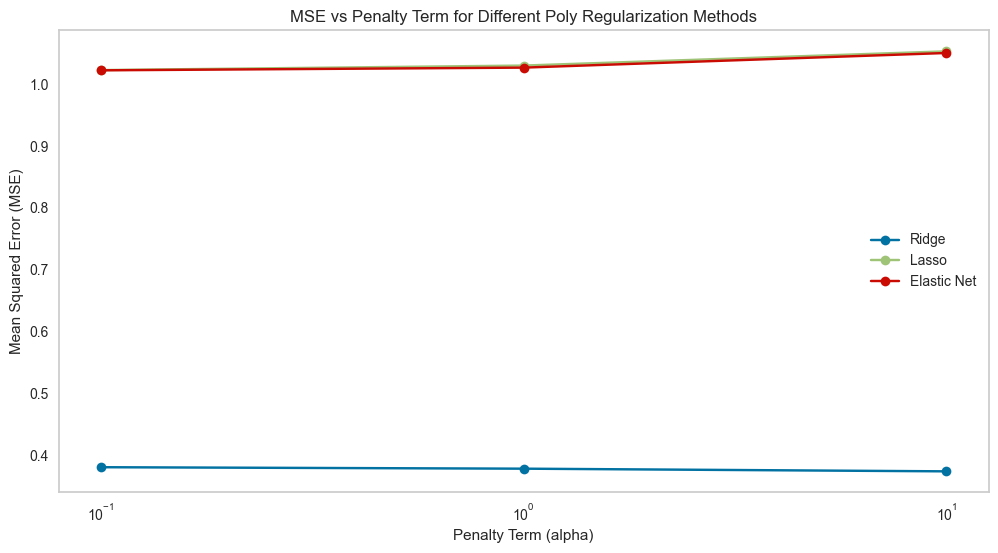

```python
# Plotting the results
plt.figure(figsize=(12, 6))
plt.plot(penalty_terms, ridge_mse, marker='o', label='Ridge')
plt.plot(penalty_terms, lasso_mse, marker='o', label='Lasso')
plt.plot(penalty_terms, elastic_net_mse, marker='o', label='Elastic Net')
plt.xscale('log')
plt.xlabel('Penalty Term (alpha)')
plt.ylabel('Mean Squared Error (MSE)')
plt.title('MSE vs Penalty Term for Different Poly Regularization Methods')
plt.legend()
plt.grid()
plt.show()
```

```python
# Hyperparameter values to explore
learning_rates = [0.001, 0.01, 0.1]
batch_sizes = [1, 100, 1000]
results = []
print("POLY SGD MSE\n")
for learning_rate in learning_rates:
    for batch_size in batch_sizes:

        max_iter = 1000 // batch_size
        sgd_pipeline = create_pipeline(SGDRegressor(max_iter=max_iter, tol=1e-3, learning_rate='constant', eta0=learning_rate, random_state=42))

        sgd_scores = cross_val_score(sgd_pipeline, X_train, y_train, cv=kf, scoring='neg_mean_squared_error')
        mean_score = -sgd_scores.mean()
        print(f"Poly Learning rate({learning_rate}) batch size {batch_size}: {mean_score}")

        results.append((learning_rate, batch_size, mean_score))
```

```
POLY SGD MSE

Poly Learning rate(0.001) batch size 1: 1.9608054430324227
Poly Learning rate(0.001) batch size 100: 1.9608054430324227
Poly Learning rate(0.001) batch size 1000: 2.0807115183816234
Poly Learning rate(0.01) batch size 1: 2.0235241017934875
Poly Learning rate(0.01) batch size 100: 2.0235241017934875
Poly Learning rate(0.01) batch size 1000: 1.9971077801978347
Poly Learning rate(0.1) batch size 1: 3.024741423569761
Poly Learning rate(0.1) batch size 100: 2.826262242205569
Poly Learning rate(0.1) batch size 1000: 2.253276238365509
```

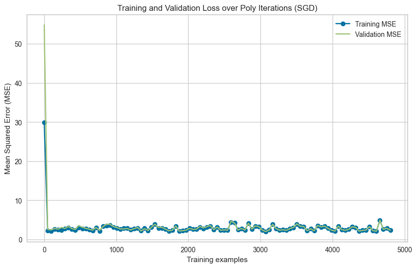

```python
train_scores, valid_scores = [], []
train_sizes = range(1, len(X_train), len(X_train) // 100)
for size in train_sizes:
    sgd_pipeline.fit(X_train[:size], y_train[:size])
    train_scores.append(mean_squared_error(y_train[:size], sgd_pipeline.predict(X_train[:size])))
    valid_scores.append(mean_squared_error(y_test, sgd_pipeline.predict(X_test)))

plt.figure(figsize=(10,6))
plt.plot(train_sizes, train_scores, label='Training MSE', marker='o')
plt.plot(train_sizes, valid_scores, label='Validation MSE', marker='x')
plt.legend()
plt.xlabel('Training examples')
plt.ylabel('Mean Squared Error (MSE)')
plt.title('Training and Validation Loss over Poly Iterations (SGD)')
plt.show()
```

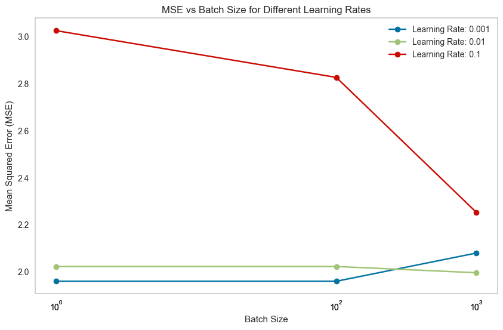

```python
results = np.array(results)
learning_rates = results[:, 0]
batch_sizes = results[:, 1]
mse_values = results[:, 2]

# Visualize results
plt.figure(figsize=(10, 6))
for lr in np.unique(learning_rates):
    mask = learning_rates == lr
    plt.plot(batch_sizes[mask], mse_values[mask], marker='o', label=f'Learning Rate: {lr}')

plt.xscale('log')
plt.xlabel('Batch Size')
plt.ylabel('Mean Squared Error (MSE)')
plt.title('MSE vs Batch Size for Different Learning Rates')
plt.xticks(batch_sizes)
plt.legend()
plt.grid()
plt.show()
```

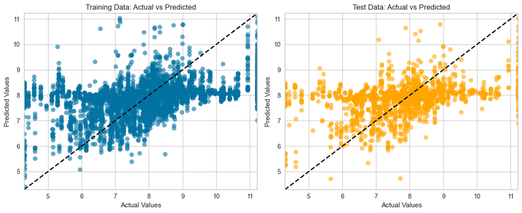

```python
lin_reg.fit(X_train_poly, y_train)

y_train_pred = lin_reg.predict(X_train_poly)
y_test_pred = lin_reg.predict(X_test_poly)

# Visualizing Training Data
plt.figure(figsize=(12, 5))

# Training set predictions
plt.subplot(1, 2, 1)
plt.scatter(y_train, y_train_pred, alpha=0.6)
plt.plot([y_train.min(), y_train.max()], [y_train.min(), y_train.max()], 'k--', lw=2)
plt.title('Training Data: Actual vs Predicted')
plt.xlabel('Actual Values')
plt.ylabel('Predicted Values')
plt.xlim([y_train.min(), y_train.max()])
plt.ylim([y_train.min(), y_train.max()])

# Test set predictions
plt.subplot(1, 2, 2)
plt.scatter(y_test, y_test_pred, alpha=0.6, color='orange')
plt.plot([y_test.min(), y_test.max()], [y_test.min(), y_test.max()], 'k--', lw=2)
plt.title('Test Data: Actual vs Predicted')
plt.xlabel('Actual Values')
plt.ylabel('Predicted Values')
plt.xlim([y_test.min(), y_test.max()])
plt.ylim([y_test.min(), y_test.max()])

plt.tight_layout()
plt.show()
```

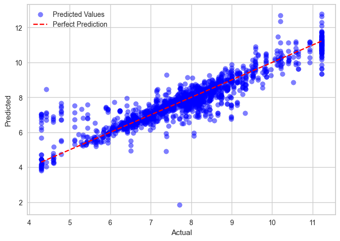

```python
ridge_model = Ridge(alpha=10.0)
ridge_model.fit(X_train_poly, y_train)
poly_ridge_pred = ridge_model.predict(X_test_poly)
mse = mean_squared_error(y_test, y_pred)

plt.scatter(y_test, poly_ridge_pred,color='blue', label='Predicted Values', alpha=0.5)
plt.plot([min(y_test), max(y_test)], [min(y_test), max(y_test)], color='red', linestyle='--', label='Perfect Prediction')
plt.xlabel('Actual')
plt.ylabel('Predicted')
plt.legend()
plt.show()
```